# Bike Sharing Dataset

**Analysis by Edgar Ortega**

Dataset obtained from the UCI Machine Learning Respository: https://archive.ics.uci.edu/ml/datasets/Bike+Sharing+Dataset

## Background

Bike sharing systems are a new generation of traditional bike rentals where the whole process from membership, rental, and returns has become automatic. Through these systems, a user is able to easily rent a bike from a particular location and return it at another location.

While using this bike sharing service the duration of travel, departure, and arrival positions are explicitly recorded. This feature turns bike sharing system into a virtual sensor network that can be used for sensing mobility in the city. Hence, it is expected that most important events in the city could be detected by monitoring this data.

## Dataset Potential

=========================================

It is believed that bike-sharing rental process is highly correlated to the environmental and seasonal settings. For instance rental behavior can be affected by, weather conditions, precipitation, day of week, season, hour of the day, etc. The core data set is related to the two-year historical log corresponding to years 2011 and 2012 from Capital Bikeshare system, Washington D.C., USA which is publicly available in http://capitalbikeshare.com/system-data. The data was aggregated on an hourly and daily basis. Then the corresponding weather and seasonal information was added from http://www.freemeteo.com.

## Tasks

=========================================

-Effects of town events on number of bike rentals

-How weather effects the number of bike rentals

-Predict the bike rental count hourly or daily based on the environmental and seasonal settings.

# How Town Events Effect Bike Rentals

Figures 1 and 2 depict the number of registered and unregistered users during a particular day between years 2011 and 2012. There were 365 days in 2011 and 366 days in 2012. Thus, days on the x-axis between 1 and 365 correspond to year 2011 and days 366 through 731 correspond to year 2012.

By taking a look at the number of registered users who used this bike share serives on a particular day in 2011 and 2012 **(Figure 1)**, we see a general increase in the number of registered users over time. However, there doesn't seem to be any sudden increase in users for any particular day. Which is what we would expect to see during an event.

The best way to see the effects of town events on bike rentals, is to look at the number of unregistered (casual) users we have on a given day.

### Figure 1

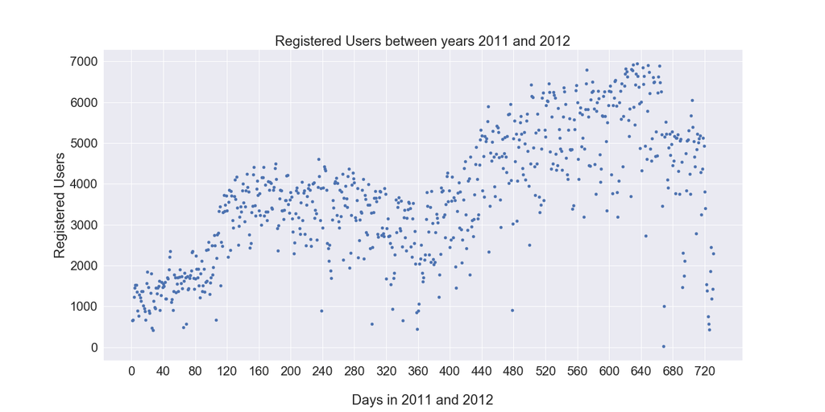

In **figure 2**, we see that the number of unregistered users using the serivice is more scattered. But, we are now able to point out days where there is a spike in usage.

Lets look at a day in 2011 and 2012 where we see the highest count of unregistered users. These are the larger red dots in **figure 2**. In 2011 this point lies between days 160 and 200. While in 2012 this point lies between days 480 and 520.

**The left 🔴 corresponds to date (2011-07-04).**

**The right 🔴 corresponds to date (2012-05-19).**

The day with the highest count of unregistered users in 2011 was during the Fourth of July. This makes sense, but what caused the highest count in 2012? A Google search of Washington DC 2012-05-19 brought up an event called 'Survive DC', which occured on that day. This is an example of how we are able to see a correlation between town events and number of unregistered users using the bike share service.

### Figure 2

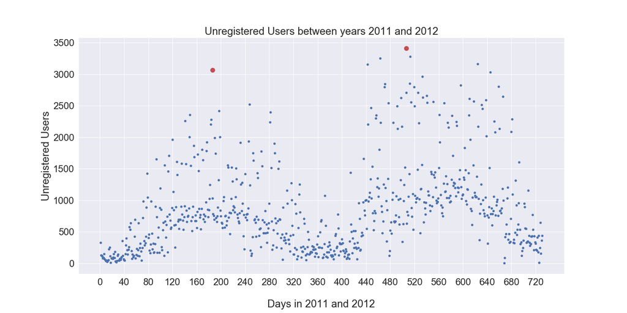

# Exploratory Data Analysis

### **Weather effects on bike rentals**

**Figures 3, 4, and 5** are box plots depicting the relationship between number of rentals per hour and weather conditions. A fourth weather condition corresponding to harsh weather only had 3 data points, and was omitted from the plots. This suggests that users prefered not to use the service during harsh weather, which is to be expected.

In **Figure 3** we see the count of casual bike users per hour plotted against weather conditions. Most of the usage from casual renters comes between the hours of 12PM to 6PM when the weather is clear.

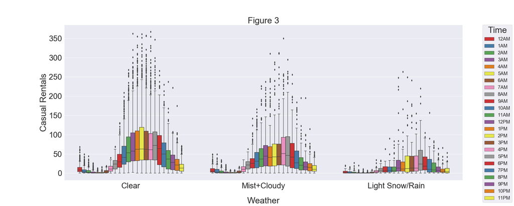

**Figures 4 and 5** show the count of registered bike users per hour plotted against weather conditions. **Figure 5** provides a zoomed in look into weather conditions 'Clear' and 'Mist+Cloudy'. There is a noticeable increase in hourly usage compared to casual renters. Notice the significant increase between hours 7AM-8AM and 5PM-6PM. Based on these plots, we can assume many of the registered bike users use these bikes as part of their daily commute during most weather conditions. However, most registered users prefer to use the bikes during Clear or Misty/Cloudy conditions.

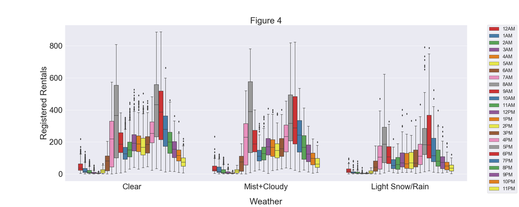

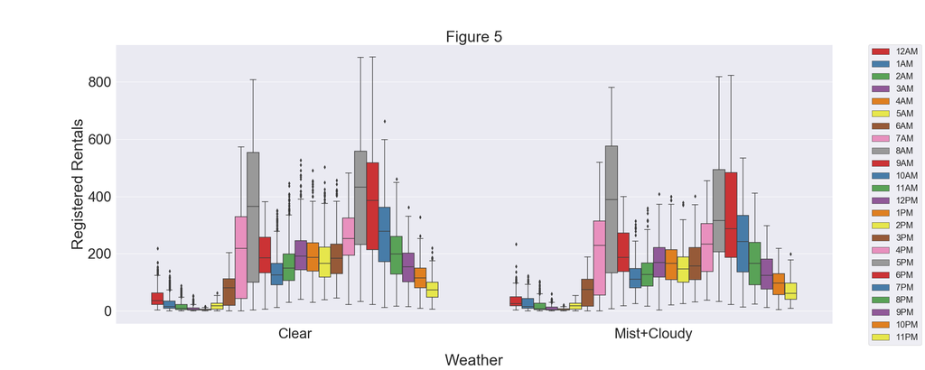

# Building Plots and Prediction Model

### **Import Libraries**

```python
import pandas as pd
import matplotlib.pyplot as plt
plt.rcParams["patch.force_edgecolor"] = True
import numpy as np
import seaborn as sns
```

**Read data from csv file and look at header**

- hour.csv : bike sharing counts aggregated on hourly basis. Records: 17379 hours
- day.csv - bike sharing counts aggregated on daily basis. Records: 731 days
- instant: record index
  - **dteday** : date
  - **season** : season (1:springer, 2:summer, 3:fall, 4:winter)
  - **yr** : year (0: 2011, 1:2012)
  - **mnth** : month ( 1 to 12)
  - **hr** : hour (0 to 23)
  - **holiday** : weather day is holiday or not (extracted from http://dchr.dc.gov/page/holiday-schedule)
  - **weekday** : day of the week
  - **workingday** : if day is neither weekend nor holiday is 1, otherwise is 0.
  - **weathersit** :
    - 1: Clear, Few clouds, Partly cloudy, Partly cloudy
    - 2: Mist + Cloudy, Mist + Broken clouds, Mist + Few clouds, Mist
    - 3: Light Snow, Light Rain + Thunderstorm + Scattered clouds, Light Rain + Scattered clouds
    - 4: Heavy Rain + Ice Pallets + Thunderstorm + Mist, Snow + Fog
  - **temp** : Normalized temperature in Celsius. The values are divided to 41 (max)
  - **atemp**: Normalized feeling temperature in Celsius. The values are divided to 50 (max)
  - **hum**: Normalized humidity. The values are divided to 100 (max)
  - **windspeed**: Normalized wind speed. The values are divided to 67 (max)
  - **casual**: count of casual users
  - **registered**: count of registered users
  - **cnt**: count of total rental bikes including both casual and registered

```python
hr = pd.read_csv('hour.csv')
day = pd.read_csv('day.csv')
```

```python
hr.head()
```

|  | instant | dteday | season | yr | mnth | hr | holiday | weekday | workingday | weathersit | temp | atemp | hum | windspeed | casual | registered | cnt |
| --- | --- | --- | --- | --- | --- | --- | --- | --- | --- | --- | --- | --- | --- | --- | --- | --- | --- |
| 0 | 1 | 2011-01-01 | 1 | 0 | 1 | 0 | 0 | 6 | 0 | 1 | 0.24 | 0.2879 | 0.81 | 0.0 | 3 | 13 | 16 |
| 1 | 2 | 2011-01-01 | 1 | 0 | 1 | 1 | 0 | 6 | 0 | 1 | 0.22 | 0.2727 | 0.80 | 0.0 | 8 | 32 | 40 |
| 2 | 3 | 2011-01-01 | 1 | 0 | 1 | 2 | 0 | 6 | 0 | 1 | 0.22 | 0.2727 | 0.80 | 0.0 | 5 | 27 | 32 |
| 3 | 4 | 2011-01-01 | 1 | 0 | 1 | 3 | 0 | 6 | 0 | 1 | 0.24 | 0.2879 | 0.75 | 0.0 | 3 | 10 | 13 |
| 4 | 5 | 2011-01-01 | 1 | 0 | 1 | 4 | 0 | 6 | 0 | 1 | 0.24 | 0.2879 | 0.75 | 0.0 | 0 | 1 | 1 |

```python
day.head()
```

|  | instant | dteday | season | yr | mnth | holiday | weekday | workingday | weathersit | temp | atemp | hum | windspeed | casual | registered | cnt |
| --- | --- | --- | --- | --- | --- | --- | --- | --- | --- | --- | --- | --- | --- | --- | --- | --- |
| 0 | 1 | 2011-01-01 | 1 | 0 | 1 | 0 | 6 | 0 | 2 | 0.344167 | 0.363625 | 0.805833 | 0.160446 | 331 | 654 | 985 |
| 1 | 2 | 2011-01-02 | 1 | 0 | 1 | 0 | 0 | 0 | 2 | 0.363478 | 0.353739 | 0.696087 | 0.248539 | 131 | 670 | 801 |
| 2 | 3 | 2011-01-03 | 1 | 0 | 1 | 0 | 1 | 1 | 1 | 0.196364 | 0.189405 | 0.437273 | 0.248309 | 120 | 1229 | 1349 |
| 3 | 4 | 2011-01-04 | 1 | 0 | 1 | 0 | 2 | 1 | 1 | 0.200000 | 0.212122 | 0.590435 | 0.160296 | 108 | 1454 | 1562 |
| 4 | 5 | 2011-01-05 | 1 | 0 | 1 | 0 | 3 | 1 | 1 | 0.226957 | 0.229270 | 0.436957 | 0.186900 | 82 | 1518 | 1600 |

### **Creating Scatter Plots (casual vs. instant) and (registered vs. instant)**

[output not shown]

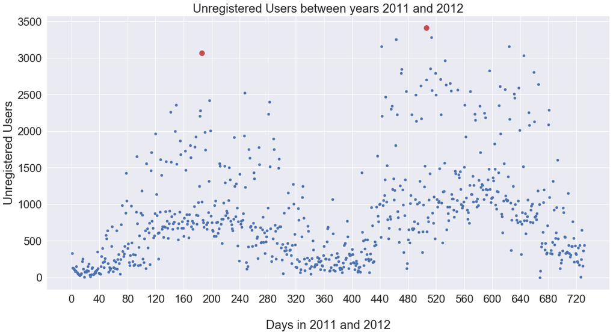

```python
day.plot.scatter(x='instant',y='casual',figsize=(20,10),xticks=(np.arange(0,731,40)))
plt.plot(day['instant'][185],day['casual'][184],'ro',markersize=10)
plt.plot(day['instant'][505],day['casual'][504],'ro',markersize=10)
plt.title('Unregistered Users between years 2011 and 2012')
plt.xlabel('Days in 2011 and 2012',labelpad=30)
plt.ylabel('Unregistered Users')
plt.savefig('Unregistered.png')
```

[output not shown]

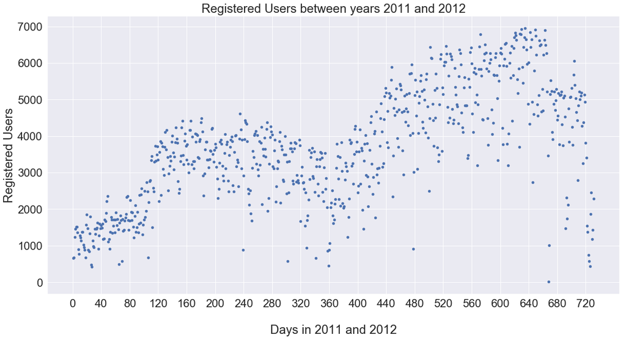

```python
day.plot.scatter(x='instant',y='registered',figsize=(20,10),xticks=(np.arange(0,731,40)))
plt.title('Registered Users between years 2011 and 2012')
plt.xlabel('Days in 2011 and 2012',labelpad=30)
plt.ylabel('Registered Users')
plt.savefig('Registered.png')
```

**Grabbing the dates corresponding to the highest count of unregistered users in 2011 and 2012.**

```python
day[day['casual']==day['casual'].loc[150:200].max()]
```

|  | instant | dteday | season | yr | mnth | holiday | weekday | workingday | weathersit | temp | atemp | hum | windspeed | casual | registered | cnt |
| --- | --- | --- | --- | --- | --- | --- | --- | --- | --- | --- | --- | --- | --- | --- | --- | --- |
| 184 | 185 | 2011-07-04 | 3 | 0 | 7 | 1 | 1 | 0 | 2 | 0.726667 | 0.665417 | 0.637917 | 0.081479 | 3065 | 2978 | 6043 |

```python
day[day['casual']==day['casual'].loc[480:520].max()]
```

|  | instant | dteday | season | yr | mnth | holiday | weekday | workingday | weathersit | temp | atemp | hum | windspeed | casual | registered | cnt |
| --- | --- | --- | --- | --- | --- | --- | --- | --- | --- | --- | --- | --- | --- | --- | --- | --- |
| 504 | 505 | 2012-05-19 | 2 | 1 | 5 | 0 | 6 | 0 | 1 | 0.6 | 0.566908 | 0.45625 | 0.083975 | 3410 | 4884 | 8294 |

```python
hr.head()
```

|  | instant | dteday | season | yr | mnth | hr | holiday | weekday | workingday | weathersit | temp | atemp | hum | windspeed | casual | registered | cnt |
| --- | --- | --- | --- | --- | --- | --- | --- | --- | --- | --- | --- | --- | --- | --- | --- | --- | --- |
| 0 | 1 | 2011-01-01 | 1 | 0 | 1 | 0 | 0 | 6 | 0 | 1 | 0.24 | 0.2879 | 0.81 | 0.0 | 3 | 13 | 16 |
| 1 | 2 | 2011-01-01 | 1 | 0 | 1 | 1 | 0 | 6 | 0 | 1 | 0.22 | 0.2727 | 0.80 | 0.0 | 8 | 32 | 40 |
| 2 | 3 | 2011-01-01 | 1 | 0 | 1 | 2 | 0 | 6 | 0 | 1 | 0.22 | 0.2727 | 0.80 | 0.0 | 5 | 27 | 32 |
| 3 | 4 | 2011-01-01 | 1 | 0 | 1 | 3 | 0 | 6 | 0 | 1 | 0.24 | 0.2879 | 0.75 | 0.0 | 3 | 10 | 13 |
| 4 | 5 | 2011-01-01 | 1 | 0 | 1 | 4 | 0 | 6 | 0 | 1 | 0.24 | 0.2879 | 0.75 | 0.0 | 0 | 1 | 1 |

**Build a dictionary to hold corresponding values**

```python
dys = {0:'Mon',1:'Tues',2:'Wed',3:'Thur',4:'Fri',5:'Sat',6:'Sun'}
hrs = {0:'12AM',1:'1AM',2:'2AM',3:'3AM',4:'4AM',5:'5AM',6:'6AM',7:'7AM',8:'8AM',9:'9AM',10:'10AM',11:'11AM',12:'12PM',
      13:'1PM',14:'2PM',15:'3PM',16:'4PM',17:'5PM',18:'6PM',19:'7PM',20:'8PM',21:'9PM',22:'10PM',23:'11PM'}
sea = {1:'Spring',2:'Summer',3:'Fall',4:'Winter'}
weather = {1:'Clear',2:'Mist+Cloudy',3:'Light Snow/Rain',4:'Heavy Rain'}
year = {0: 2011, 1:2012}
month = {1:'Jan', 2:'Feb',3:'Mar',4:'Apr',5:'May',6:'June',7:'July',8:'Aug',9:'Sept',10:'Oct',11:'Nov',12:'Dec'}
```

**Apply the changes**

```python
hr['season'] = hr['season'].apply(lambda i: sea[i])
hr['hr'] = hr['hr'].apply(lambda i: hrs[i])
hr['weekday'] = hr['weekday'].apply(lambda i: dys[i])
hr['weathersit'] = hr['weathersit'].apply(lambda i: weather[i])
hr['yr'] = hr['yr'].apply(lambda i: year[i])
hr['mnth'] = hr['mnth'].apply(lambda i: month[i])
```

```python
day['season'] = day['season'].apply(lambda i: sea[i])
day['weekday'] = day['weekday'].apply(lambda i: dys[i])
day['weathersit'] = day['weathersit'].apply(lambda i: weather[i])
day['yr'] = day['yr'].apply(lambda i: year[i])
day['mnth'] = day['mnth'].apply(lambda i: month[i])
```

**Lets see our results**

```python
hr.head()
```

|  | instant | dteday | season | yr | mnth | hr | holiday | weekday | workingday | weathersit | temp | atemp | hum | windspeed | casual | registered | cnt |
| --- | --- | --- | --- | --- | --- | --- | --- | --- | --- | --- | --- | --- | --- | --- | --- | --- | --- |
| 0 | 1 | 2011-01-01 | Spring | 2011 | Jan | 12AM | 0 | Sun | 0 | Clear | 0.24 | 0.2879 | 0.81 | 0.0 | 3 | 13 | 16 |
| 1 | 2 | 2011-01-01 | Spring | 2011 | Jan | 1AM | 0 | Sun | 0 | Clear | 0.22 | 0.2727 | 0.80 | 0.0 | 8 | 32 | 40 |
| 2 | 3 | 2011-01-01 | Spring | 2011 | Jan | 2AM | 0 | Sun | 0 | Clear | 0.22 | 0.2727 | 0.80 | 0.0 | 5 | 27 | 32 |
| 3 | 4 | 2011-01-01 | Spring | 2011 | Jan | 3AM | 0 | Sun | 0 | Clear | 0.24 | 0.2879 | 0.75 | 0.0 | 3 | 10 | 13 |
| 4 | 5 | 2011-01-01 | Spring | 2011 | Jan | 4AM | 0 | Sun | 0 | Clear | 0.24 | 0.2879 | 0.75 | 0.0 | 0 | 1 | 1 |

Notice 'Heavy Rain' only has 3 entries. I'll remove those rows from our DataFrame in order to make our plots look a little cleaner.

```python
hr['weathersit'].value_counts()
```

```
Clear              11413
Mist+Cloudy         4544
Light Snow/Rain     1419
Heavy Rain             3
Name: weathersit, dtype: int64
```

```python
hr = hr[hr.weathersit != 'Heavy Rain']
```

```python
hr['weathersit'].value_counts()
```

```
Clear              11413
Mist+Cloudy         4544
Light Snow/Rain     1419
Name: weathersit, dtype: int64
```

We know only have 3 types of weather conditions to consider